# The Ball Python Project

## Alison Qiu

The ball python (Python regius) is a snake native to Africa that is so-called due to its tendency to curl into a ball. Likely due to their docile temperament, ball pythons are the most popular pet snake and over 7,500 distinct morphs currently exist. Some of the most commonly recognized morphs are determined by Mendelian dominant or recessive genes, allowing for even more striking phenotypes to result from a combination of such genes. Sometimes, a breeder will breed two snakes with such a dramatic combination of genes that it can become hard to tell exactly which genes are present in the offspring snakes.

You can find a primer on ball python genes here: http://kpexotics.com/Main/2021/08/31/genetic-primer/. Here is the wikipedia page for the snake species in general: https://en.wikipedia.org/wiki/Ball_python

The motivation of this project is to explore how ball pythons are priced according to their genes, sex and age, as well as training a neural network to identify the genes present in a ball python given an image of it. Below, I've provided all the imports I've used for the project.

```python
from selenium import webdriver
from selenium.webdriver.chrome.service import Service
from selenium.webdriver.common.by import By
import time
import datetime
from PIL import Image
import random
from matplotlib import image

import requests
from io import BytesIO

import tensorflow as tf
from tensorflow import keras
from tensorflow.keras import layers
print('Tensorflow/Keras: %s' % keras.__version__) # print version
from keras.models import Sequential # for creating a linear stack of layers for our Neural Network
from keras import Input # for instantiating a keras tensor
from keras.layers import Dense, Conv2D, MaxPool2D, Flatten, Dropout, Concatenate # for adding Concolutional and densely-connected NN layers.
from tensorflow.keras.layers import BatchNormalization
from keras.optimizers import SGD

# Data manipulation
import pandas as pd # for data manipulation
print('pandas: %s' % pd.__version__) # print version
import numpy as np # for data manipulation
print('numpy: %s' % np.__version__) # print version

# Sklearn
import sklearn # for model evaluation
print('sklearn: %s' % sklearn.__version__) # print version
from sklearn.model_selection import train_test_split # for splitting the data into train and test samples
from sklearn.metrics import classification_report # for model evaluation metrics
from sklearn.preprocessing import OrdinalEncoder # for encoding labels

from sklearn import datasets, linear_model
from sklearn.linear_model import LinearRegression
from sklearn.preprocessing import PolynomialFeatures
import statsmodels.api as sm
from scipy import stats

# Visualization
import cv2 # for ingesting images
print('OpenCV: %s' % cv2.__version__) # print version
import matplotlib
import matplotlib.pyplot as plt # for showing images
print('matplotlib: %s' % matplotlib.__version__) # print version
import seaborn as sns

# Regexing and date processing
import re
import datetime

# Other utilities
import sys
import os
```

```
Tensorflow/Keras: 2.11.0
pandas: 1.3.4
numpy: 1.20.3
sklearn: 0.24.2
OpenCV: 4.6.0
matplotlib: 3.4.3
```

## Prelude: Web Scraping

Since there aren't very many datasets on ball python images to be found online, I have decided to scrape MorphMarket for images of ball pythons. MorphMarket is a website that allows breeders to list reptiles for sale, and it has a big ball python market. It displays 20 animals per page with a fixed thumbnail size, which keeps the image sizes consistent for when the neural network trains on them.

Selenium is a powerful library that allows you to build your own web scraper. To use it, you call webdriver's browser methods such as Chrome() or Firefox() to open up a crawler in the browser of your choice--I have elected to use Firefox. I will note that before I resorted to Selenium, I had attempted to use BeautifulSoup4 to scrape the listings. However, attempting to search for specific elements, such as snake thumbnail objects, would result in either the desired elements appearing to vanish from the tree or a bunch of unrelated elements being found instead.

You may notice that from looking at documentation for Selenium that a number of different methods for finding web elements--such as 'find_element_by_tag_name' or 'find_element_by_css_selector'--are provided. These methods are for an older version of Selenium and will not work with this version of Python!! Instead, use the newer find_element method, which accepts two arguments--the first of which is the item you are searching on, such as By.TAG_NAME or By.CSS_SELECTOR.

If you have decided to use the CSV files that I've already provided, then you can skip running the web crawler code below. However, if you want to gather your own MorphMarket data, or gather data on different ball python morphs such as albino or pastel, then you'll want to run the code below. The first variable, 'pages_num_pages_csvs', is a list of triples (URL, number of pages, csv name). The web crawler will iterate through the list, opening a new driver for the current URL, then navigating through the specified number of pages. Once it is done moving through the pages, it writes the scraped data into the specified CSV name.

Most sites generally don't appreciate being spammed with requests in a short amount of time. If any client makes too many requests to a server in a short amount of time, the server will often reject further requests with a 403 error. This can mess up the web crawler. I've added in delays between each page and each URL such that the number of requests does not cause MorphMarket to reject the web crawler--the exact values were determined through trial and error.

To gain access to more ball python images, I had the web crawler log in to my MorphMarket account to be able to access historical listings. I have replaced the corresponding fields in the webcrawler code with placeholder strings. You will want to create your own MorphMarket account, then replace the placeholder strings.

```python
# List of page, # pages, csv filename triples to crawl a filtered morphmarket search page.
pages_num_pages_csvs = [('https://www.morphmarket.com/all/c/all?cat=2&sex=&maturity=0&min_weight=0&max_weight=1000000&prey_state=0&prey_food=0&min_genes=0&max_genes=1&traits=Normal&neg_traits=&min_price=0&max_price=1000000&cur=USD&epoch=21&store=&nearby_location=&lat=&lng=&radius=&country=&export=&sort=nfs&layout=grid&page=1', 10, 'normals.csv'),\
                        ('https://www.morphmarket.com/all/c/all?cat=2&sex=&maturity=0&min_weight=0&max_weight=1000000&prey_state=0&prey_food=0&min_genes=0&max_genes=1&traits=Clown&neg_traits=&min_price=0&max_price=1000000&cur=USD&epoch=21&store=&nearby_location=&lat=&lng=&radius=&country=&export=&sort=nfs&layout=grid', 10, 'single_gene_clowns.csv'),\
                        ('https://www.morphmarket.com/all/c/all?cat=2&sex=&maturity=0&min_weight=0&max_weight=1000000&prey_state=0&prey_food=0&min_genes=0&max_genes=1&traits=Piebald&neg_traits=&min_price=0&max_price=1000000&cur=USD&epoch=21&store=&nearby_location=&lat=&lng=&radius=&country=&export=&sort=nfs&layout=grid', 10, 'single_gene_piebalds.csv'),\
                        ('https://www.morphmarket.com/all/c/all?cat=2&sex=&maturity=0&min_weight=0&max_weight=1000000&prey_state=0&prey_food=0&min_genes=0&max_genes=2&traits=Piebald%2CClown&neg_traits=&min_price=0&max_price=1000000&cur=USD&epoch=21&store=&nearby_location=&lat=&lng=&radius=&country=&export=&sort=nfs&layout=grid', 10, 'clown_piebalds.csv'),\
                        ('https://www.morphmarket.com/all/c/all?cat=2&sex=&maturity=0&min_weight=0&max_weight=1000000&prey_state=0&prey_food=0&min_genes=0&max_genes=1&traits=Banana&neg_traits=&min_price=0&max_price=1000000&cur=USD&epoch=21&store=&nearby_location=&lat=&lng=&radius=&country=&export=&sort=nfs&layout=grid', 10, 'single_gene_bananas.csv'),\
                        ('https://www.morphmarket.com/all/c/all?cat=2&sex=&maturity=0&min_weight=0&max_weight=1000000&prey_state=0&prey_food=0&min_genes=0&max_genes=2&traits=Banana%2CClown&neg_traits=&min_price=0&max_price=1000000&cur=USD&epoch=21&store=&nearby_location=&lat=&lng=&radius=&country=&export=&sort=nfs&layout=grid', 10, 'banana_clowns.csv'),\
                        ('https://www.morphmarket.com/all/c/all?cat=2&sex=&maturity=0&min_weight=0&max_weight=1000000&prey_state=0&prey_food=0&min_genes=0&max_genes=2&traits=Banana%2CPiebald&neg_traits=&min_price=0&max_price=1000000&cur=USD&epoch=21&store=&nearby_location=&lat=&lng=&radius=&country=&export=&sort=nfs&layout=grid', 10, 'banana_piebalds.csv'),\
                        ('https://www.morphmarket.com/all/c/all?cat=2&sex=&maturity=0&min_weight=0&max_weight=1000000&prey_state=0&prey_food=0&min_genes=0&max_genes=3&traits=Banana%2CPiebald%2CClown&neg_traits=&min_price=0&max_price=1000000&cur=USD&epoch=21&store=&nearby_location=&lat=&lng=&radius=&country=&export=&sort=nfs&layout=grid', 1, 'banana_clown_piebalds.csv')]

df_list = list()
for page,num_pages,csv in pages_num_pages_csvs:
    driver = webdriver.Firefox()
    driver.get(page)
    h = 0

    # Replace the placeholder elements with your MorphMarket username and password.
    inputElement = driver.find_element(By.ID, "id_login")
    inputElement.send_keys('placeholder')

    password = driver.find_element(By.ID, "id_password")
    password.send_keys('placeholder')

    button = driver.find_element(By.CSS_SELECTOR, "button.base-mm-design-button.base-mm-design-button-primary.base-mm-design-button-md.base-mm-design-button-full-width.form-container-margin-m.primaryAction")
    button.click()
    snakes_list = list()
    while h < num_pages:
        snakes = driver.find_elements(By.CSS_SELECTOR, "div.col-lg-3.col-md-4.col-sm-4.col-6.item-col.move-up");
        i = 0
        while i < len(snakes):
            snake_current_dict = dict.fromkeys(['img_url',
                                                'sex',\
                                                'traits',\
                                                'birth',\
                                                'weight',\
                                                'diet',\
                                                'breeder',\
                                                'location',\
                                                'price',\
                                                'payments',\
                                                'shipping',\
                                                'trades',\
                                                'first_posted',\
                                                'last_updated',\
                                                'animal_id',\
                                                'group_id',\
                                                'origin',\
                                                'num_likes',\
                                                'snake_url']) # Listing URL.
            snake_current_dict['num_likes'] = 0
            current_snake = snakes[i]
            current_snake_a = current_snake.find_element(By.TAG_NAME, 'a')
            snake_current_dict['snake_url'] = current_snake_a.get_attribute('href')
            snake_img_url = current_snake.find_element(By.CLASS_NAME, 'snake-thumb')
            snake_current_dict['img_url'] = snake_img_url.get_attribute('src')
            snake_current_dict['img'] = Image.open(BytesIO(requests.get(snake_img_url.get_attribute('src')).content)) if snake_img_url.get_attribute('alt') != 'No image' else None
            snake_breeder = current_snake.find_element(By.CSS_SELECTOR, 'div.second-row.clearfix')
            snake_breeder = snake_breeder.find_element(By.CSS_SELECTOR, 'div.store.float-left')
            snake_current_dict['breeder'] = snake_breeder.text
            current_snake.click()
            snake_title = driver.find_element(By.CSS_SELECTOR, 'div.title-container.d-flex.justify-content-center.align-items-center.flex-wrap')
            snake_title = snake_title.find_elements(By.TAG_NAME, 'span')
            snake_current_dict['title'] = snake_title[0].text
            snake_likes = driver.find_element(By.CSS_SELECTOR, "span.badge.badge-secondary.badge-pill.num-likes")
            snake_current_dict['num_likes'] = snake_likes.text if snake_likes.text != '' else 0
            snake_details = driver.find_element(By.CLASS_NAME, 'details')
            snake_deets = snake_details.find_elements(By.TAG_NAME, 'dd')
            snake_dts = snake_details.find_elements(By.TAG_NAME, 'dt')
            j = 0
            while j < len(snake_dts):
                detail = snake_deets[j]
                detail_id = snake_dts[j].text
                if detail_id == 'Sex:':
                    try:
                        snake_sex_i = detail.find_element(By.TAG_NAME, 'i')
                        snake_current_dict['sex'] = snake_sex_i.get_attribute('alt')
                    except:
                        snake_current_dict['sex'] = '?'
                if detail_id == 'Traits:':
                    snake_current_dict['traits'] = set()
                    snake_traits = detail.find_elements(By.TAG_NAME, 'span')
                    for snake_trait in snake_traits:
                        snake_current_dict['traits'].add(snake_trait.text)
                if detail_id == 'Birth:':
                    snake_current_dict['birth'] = detail.text
                if detail_id == 'Weight:':
                    snake_current_dict['weight'] = detail.text
                if detail_id == 'Diet:':
                    snake_current_dict['diet'] = detail.text
                #if detail_id == 'Breeder:':
                    #snake_store_link = detail.find_element(By.CLASS_NAME, 'position-relative')
                    #snake_store_link = snake_store_link.find_element(By.TAG_NAME, 'a')
                    #snake_current_dict['breeder'] = snake_store_link.text
                if detail_id == 'Location:':
                    snake_current_dict['location'] = detail.text
                if detail_id == 'Price:':
                    snake_current_dict['price'] = detail.text
                if detail_id == 'Payments:':
                    snake_current_dict['payments'] = detail.text
                if detail_id == 'Shipping:':
                    snake_current_dict['shipping'] = detail.text
                if detail_id == 'Trades:':
                    snake_current_dict['trades'] = detail.text
                if detail_id == 'First Posted:':
                    snake_current_dict['first_posted'] = detail.text
                if detail_id == 'Last Updated:':
                    snake_current_dict['last_updated'] = detail.text
                if detail_id == 'Animal ID:':
                    snake_current_dict['animal_id'] = detail.text
                if detail_id == 'Group ID:':
                    snake_current_dict['group_id'] = detail.text
                if detail_id == 'Origin:':
                    snake_current_dict['origin'] = detail.text
                j = j + 1
            driver.back()
            snakes = driver.find_elements(By.CSS_SELECTOR, "div.col-lg-3.col-md-4.col-sm-4.col-6.item-col.move-up");
            snakes_list.append(snake_current_dict)
            i = i + 1
        if h != num_pages - 1:
            time.sleep(80)
            pagination = driver.find_element(By.CLASS_NAME, 'pagination')
            page_items = pagination.find_elements(By.CLASS_NAME, 'page-item')
            next_page_button = page_items[len(page_items)-2]
            next_page_button.click()
        h = h + 1
    driver.close()
    snakes_df = pd.DataFrame(snakes_list)
    df_list.append(snakes_df)
    snakes_df.to_csv(path_or_buf=csv, sep = '|')
    time.sleep(600)
```

## A: Training a Neural Network to Recognize Traits in Ball Pythons

## Part 1: Data Wrangling

The way that pandas' to_csv method writes items into a csv file is that it will take the literal string representation of the object and write that into the csv file. While this is sufficient for items such as strings or integers, more complicated objects like images don't have much of their actual information stored in their string representations. Hence, if you are loading the data from the CSVs provided, then you will need to restore the images from the img_url fields given for each snake! I have provided code below to do this.

```python
csvs = ['normals.csv',\
        'single_gene_clowns.csv',\
        'single_gene_piebalds.csv',\
        'clown_piebalds.csv',\
        'single_gene_bananas.csv',\
        'banana_clowns.csv',\
        'banana_piebalds.csv',\
        'banana_clown_piebalds.csv']
df_list = list()
for csv in csvs:
    snake_df = pd.read_csv(csv, sep='|')
    i = 0
    img_list = list()
    while i < len(snake_df):
        single_snake = snake_df.iloc[i]
        if single_snake['img_url'] != 'https://via.placeholder.com/225x190?text=No+image':
            img = Image.open(BytesIO(requests.get(single_snake['img_url']).content))
        else:
            img = None
        img_list.append(img)
        i = i + 1
    snake_df['img'] = img_list
    df_list.append(snake_df)
```

The distribution of ball pythons among even the more common morphs suffers from the curse of dimensionality; because multiple morphs can be visually present on a snake, asking a neural network to distinguish between combinations of even just 8 morphs could result in many, many output classes. This is compounded by the fact that some Mendelian dominant morphs have homozygous, or "super" variants, which further complicates things. Hence, I have limited the scope of this project to distinguishing between combinations of three popular morphs: banana, piebald and clown. Below, I've created a dictionary encoding an integer to each combination of morphs.

```python
# Each class is assigned an integer. This is the dictionary mapping integers to classes.
snake_encoder = {0 : 'Normal', 1 : 'Clown', 2 : 'Piebald', 3 : 'Clown Piebald',\
                 4 : 'Banana', 5 : 'Banana Clown', 6 : 'Banana Piebald', 7: 'Banana Clown Piebald'}
```

To get an idea of the ball pythons that we'll be training the neural network on, we can use matplotlib to display an image from each class of ball python.

[figure not shown]

```python
# Now we'll use matplotlib to display images of ball pythons of each class.
random.seed(199)
fig, axs = plt.subplots(2, 4, sharey=False, tight_layout=True, figsize=(12,7), facecolor='white')
fig.suptitle('Morphs of ball pythons listed on MorphMarket', fontsize=30)
n= 0
for i in range(0,2):
    for j in range(0,4):
        axs[i,j].matshow(df_list[n].iloc[random.randint(0, len(df_list[n])-1)]['img'])
        axs[i,j].set(title=snake_encoder[n])
        n=n+1
plt.show()
```

Occasionally, breeders will mistag heterozygous recessive snakes as visuals, or conversely, mistag snakes with extra genes as single-gene snakes. For instance, the 'Piebald' ball python also happens to visually display the albino trait. Sometimes, breeders will also display multiple snakes in one image. The quality of images also tends to vary--some are very professional while others cut out a lot of the snake. Regardless, the vast majority of images should be tagged correctly. The next step in data wrangling will be to bring the data from all eight classes into a single dataframe.

```python
# Let's add all the information from the eight dataframes into one united dataframe.
united_df = pd.DataFrame(columns = ['img_url',
                                                'sex',\
                                                'traits',\
                                                'birth',\
                                                'weight',\
                                                'diet',\
                                                'breeder',\
                                                'location',\
                                                'price',\
                                                'payments',\
                                                'shipping',\
                                                'trades',\
                                                'first_posted',\
                                                'last_updated',\
                                                'animal_id',\
                                                'group_id',\
                                                'origin',\
                                                'num_likes',\
                                                'snake_url',\
                                                'img'])
united_df = df_list[0].copy()
i = 1
while i < len(df_list):
    united_df = united_df.append(df_list[i])
    i = i + 1
united_df = united_df.loc[united_df['img'].notnull()]
print("Total number of records in the united dataframe:", len(united_df))
```

```
Total number of records in the united dataframe: 1406
```

Now, let's start preparing the data for image classification. A simple way to do this is to check which traits are present for each snake, then encode them as an integer.

```python
# Now we'll encode snakes' traits into the integer classes above.
united_df['isBanana'] = united_df['traits'].apply(lambda x: 1 if "Banana" in x or "Super Banana" in x else 0)
united_df['isPiebald'] = united_df['traits'].apply(lambda x: 1 if "Piebald" in x else 0)
united_df['isClown'] = united_df['traits'].apply(lambda x: 1 if "Clown" in x else 0)
united_df['cat_encoder'] = united_df['isBanana'] * 4 + united_df['isPiebald'] * 2 + united_df['isClown']
```

```python
# Here we'll also print out the number of snakes assigned to each class, just as a sanity check.
normal = united_df.loc[united_df['cat_encoder'] == 0]
single_gene_clown = united_df.loc[united_df['cat_encoder'] == 1]
single_gene_piebald = united_df.loc[united_df['cat_encoder'] == 2]
piebald_clown = united_df.loc[united_df['cat_encoder'] == 3]
single_gene_banana = united_df.loc[united_df['cat_encoder'] == 4]
banana_clown = united_df.loc[united_df['cat_encoder'] == 5]
banana_piebald = united_df.loc[united_df['cat_encoder'] == 6]
banana_clown_piebald = united_df.loc[united_df['cat_encoder'] == 7]
print('normal count:', normal['img_url'].count())
print('single gene clown count:', single_gene_clown['img_url'].count())
print('single gene piebald count:', single_gene_piebald['img_url'].count())
print('piebald clown count:', piebald_clown['img_url'].count())
print('single gene banana count:', single_gene_banana['img_url'].count())
print('banana clown count:', banana_clown['img_url'].count())
print('banana piebald count:', banana_piebald['img_url'].count())
print('banana clown piebald count:', banana_clown_piebald['img_url'].count())
```

```
normal count: 200
single gene clown count: 200
single gene piebald count: 200
piebald clown count: 197
single gene banana count: 200
banana clown count: 200
banana piebald count: 200
banana clown piebald count: 9
```

I tried my best to include about 200 images for each class, which is small by image classification standards. However, not all classes have enough snakes, especially the triple gene combo banana clown piebald seeing as such designer combos tend to be far rarer than single-gene or double-gene combos. I do not expect the neural network to be able to classify this last class as well as the other seven. Since seven out of the eight classes are roughly balanced, the risk of the neural network getting stuck at a local minima by guessing a dominant class is relatively low.

For the purposes of image classification, we really only need a couple rows from the united dataframe. However, if you wish to do any future projects, then the additional information such as sex, price, etc. have been made available in my CSV files.

```python
# Slicing out the relevant rows for image classification and displaying the head of the dataframe.
image_classification_df = united_df[['img', 'cat_encoder']]
image_classification_df.head()
```

|  | img | cat_encoder |
| --- | --- | --- |
| 0 | <PIL.JpegImagePlugin.JpegImageFile image mode=... | 0 |
| 1 | <PIL.JpegImagePlugin.JpegImageFile image mode=... | 0 |
| 2 | <PIL.JpegImagePlugin.JpegImageFile image mode=... | 0 |
| 3 | <PIL.JpegImagePlugin.JpegImageFile image mode=... | 0 |
| 4 | <PIL.JpegImagePlugin.JpegImageFile image mode=... | 0 |

Since the dataset is quite small, we will need to be a little bit sneakier to prevent our model from overfitting to the data. One such technique that I have decided to use is data augmentation. Below, I've defined a data augmentation transformation to randomly flip and rotate snake images in the training set.

```python
data_augmentation = tf.keras.Sequential([
  layers.RandomFlip("horizontal_and_vertical"),
  layers.RandomRotation(0.2),
])
```

Now we'll define the X and y items for the neural network and prepare them as numpy arrays.

```python
X = list()
y = list()
for row in image_classification_df.iterrows():
    X.append(np.array(row[1]['img']) / 255.0)
    y.append(row[1]['cat_encoder'])
X = np.array(X)
y = np.array(y)
print("Shape of X:", X.shape)
print("Shape of y:", y.shape)
```

```
Shape of X: (1406, 190, 225, 3)
Shape of y: (1406,)
```

```python
# Splitting the X and y into training and testing portions.
X_train, X_test, y_train, y_test = train_test_split(X, y, test_size=0.2, random_state=199)

print("Shape of X_train: ", X_train.shape)
print("Shape of y_train: ", y_train.shape)
print("Shape of X_test: ", X_test.shape)
print("Shape of y_test: ", y_test.shape)
```

```
Shape of X_train:  (1124, 190, 225, 3)
Shape of y_train:  (1124,)
Shape of X_test:  (282, 190, 225, 3)
Shape of y_test:  (282,)
```

Importantly, you should only augment the training set.

```python
# Now augmenting the training set with 8 augmented images per image in the original training set. This might take a while.
augmented_X_train = list()
augmented_y_train = list()
i = 0
while i < len(X_train):
    j = 0
    while j < 8:
        augmented_img = data_augmentation(X_train[i])
        augmented_X_train.append(augmented_img)
        augmented_y_train.append(y_train[i])
        j = j + 1
    i = i + 1
augmented_X_train = np.array(augmented_X_train)
augmented_y_train = np.array(augmented_y_train)
print("Shape of augmented_X_train:", augmented_X_train.shape)
print("Shape of augmented_y_train:", augmented_y_train.shape)
```

```
Shape of augmented_X_train: (8992, 190, 225, 3)
Shape of augmented_y_train: (8992,)
```

## Part 2: Training the Neural Network

Now that we have prepared the training dataset, it's time to create the neural network. For the purposes of this project, I've decided to use the pre-trained neural network Xception, which is available from Keras. It will be frozen (prevented from updating) while I'll add a couple extra layers for our specific task.

The dense layer will be able to see the features extracted by the Xception model, then learn how to classify the ball pythons. The dropout layer is another guard against overfitting. Since there are eight classes to classify amongst, I've chosen to output eight neurons and use the softmax activation function, which outputs the probability that a given image belongs to each class.

I should note that the design of neural networks is largely an art form at the moment. I had gone through many different architectures before I settled upon this approach. Here's a source explaining how exactly to make a convolutional neural network in Keras: https://towardsdatascience.com/building-a-convolutional-neural-network-cnn-in-keras-329fbbadc5f5

```python
# Loading in the Xception model.
transfer_model = Sequential(name="Transfer-Ball-Python-Model")
transfer_model.add(keras.applications.Xception(
    weights='imagenet',  # Load weights pre-trained on ImageNet.
    input_shape=(augmented_X_train.shape[1], augmented_X_train.shape[2], augmented_X_train.shape[3]),
    include_top=False))  # Do not include the ImageNet classifier at the top.

# Now adding in my own layers for this classification problem.
transfer_model.add(Flatten(name="Transfer-Flatten-layer"))
transfer_model.add(Dense(128, activation='leaky_relu', name='Hidden-Layer-1', kernel_initializer='HeNormal')) # Hidden Layer, relu(x) = max(x, 0)
transfer_model.add(Dropout(0.3, name='Dropout-3'))
transfer_model.add(Dense(8, activation='softmax', name='Output-Layer')) # Output Layer, softmax(x) = exp(x) / tf.reduce_sum(exp(x))

# Freezing the Xception layer.
transfer_model.layers[0].trainable=False
```

While designing my model and testing it, I found SGD to be a better optimizer than 'Adam', as the loss for Adam would often times 'explode' or have my neural network be stuck at 'guess all the snakes to be banana clowns'. However, if the learning rate is too high for stochastic gradient descent, the loss may diverge altogether and become 'nan', which will inevitably 'kill' the neural network.

Because the output is encoded as a single integer that may take on eight different forms--rather than eight one-hot-encoded columns--the correct loss function to use here is 'sparse_categorical_crossentropy'. If the target values were to be one-hot-encoded, you would use the regular 'categorical_crossentropy' loss function instead.

The metric being used here is 'sparse_categorical_accuracy', which is specifically designed for this type of output. However, you can also use the regular 'accuracy' metric.

```python
# Now compiling the model with stochastic gradient descent and a learning rate of 1/1000.
opt = SGD(lr=1e-3)
transfer_model.compile(optimizer=opt, # default='rmsprop', an algorithm to be used in backpropagation
              loss='sparse_categorical_crossentropy', # Loss function to be optimized. A string (name of loss function), or a tf.keras.losses.Loss instance.
              metrics=['sparse_categorical_accuracy'], # List of metrics to be evaluated by the model during training and testing. Each of this can be a string (name of a built-in function), function or a tf.keras.metrics.Metric instance.
              loss_weights=None, # default=None, Optional list or dictionary specifying scalar coefficients (Python floats) to weight the loss contributions of different model outputs.
              weighted_metrics=None, # default=None, List of metrics to be evaluated and weighted by sample_weight or class_weight during training and testing.
              run_eagerly=None, # Defaults to False. If True, this Model's logic will not be wrapped in a tf.function. Recommended to leave this as None unless your Model cannot be run inside a tf.function.
              steps_per_execution=None # Defaults to 1. The number of batches to run during each tf.function call. Running multiple batches inside a single tf.function call can greatly improve performance on TPUs or small models with a large Python overhead.
             )
```

Now we'll start training the neural network. The number of epochs that you'll want to train on is largely a personal preference, though I've selected ten. Some datasets will be split into a train set, a validation set and a test set, where the model will intermittently predict the labels of the validation set to detect overfitting early. If you wish, you may configure the model to end its training if the validation metrics do not improve after a certain number of epochs. I've decided to have just a regular train and test split.

```python
history = transfer_model.fit(augmented_X_train, # in put data
                    augmented_y_train, # target data
                    batch_size=1, # Number of samples per gradient update. If unspecified, batch_size will default to 32.
                    epochs=10, # default=1, Number of epochs to train the model. An epoch is an iteration over the entire x and y data provided
                    verbose=1, # default='auto', ('auto', 0, 1, or 2). Verbosity mode. 0 = silent, 1 = progress bar, 2 = one line per epoch. 'auto' defaults to 1 for most cases, but 2 when used with ParameterServerStrategy.
                    callbacks=None, # default=None, list of callbacks to apply during training. See tf.keras.callbacks
                    validation_split=0, # default=0.0, Fraction of the training data to be used as validation data. The model will set apart this fraction of the training data, will not train on it, and will evaluate the loss and any model metrics on this data at the end of each epoch.
                    #validation_data=(X_test, y_test), # default=None, Data on which to evaluate the loss and any model metrics at the end of each epoch.
                    shuffle=True, # default=True, Boolean (whether to shuffle the training data before each epoch) or str (for 'batch').
                    class_weight=None, # default=None, Optional dictionary mapping class indices (integers) to a weight (float) value, used for weighting the loss function (during training only). This can be useful to tell the model to "pay more attention" to samples from an under-represented class.
                    sample_weight=None, # default=None, Optional Numpy array of weights for the training samples, used for weighting the loss function (during training only).
                    initial_epoch=0, # Integer, default=0, Epoch at which to start training (useful for resuming a previous training run).
                    steps_per_epoch=None, # Integer or None, default=None, Total number of steps (batches of samples) before declaring one epoch finished and starting the next epoch. When training with input tensors such as TensorFlow data tensors, the default None is equal to the number of samples in your dataset divided by the batch size, or 1 if that cannot be determined.
                    #validation_steps=None, # Only relevant if validation_data is provided and is a tf.data dataset. Total number of steps (batches of samples) to draw before stopping when performing validation at the end of every epoch.
                    #validation_batch_size=None, # Integer or None, default=None, Number of samples per validation batch. If unspecified, will default to batch_size.
                    #validation_freq=1, # default=1, Only relevant if validation data is provided. If an integer, specifies how many training epochs to run before a new validation run is performed, e.g. validation_freq=2 runs validation every 2 epochs.
                    max_queue_size=10, # default=10, Used for generator or keras.utils.Sequence input only. Maximum size for the generator queue. If unspecified, max_queue_size will default to 10.
                    workers=1, # default=1, Used for generator or keras.utils.Sequence input only. Maximum number of processes to spin up when using process-based threading. If unspecified, workers will default to 1.
                    use_multiprocessing=False, # default=False, Used for generator or keras.utils.Sequence input only. If True, use process-based threading. If unspecified, use_multiprocessing will default to False.
                   )
```

Once the model is done training, we can evaluate its final performance by asking it to predict the labels of the original training and test sets. Then, we'll print out the summary of how well it did classifying each of the eight classes, including the precision and recall metrics for each class.

```python
pred_labels_tr = np.array(tf.math.argmax(transfer_model.predict(X_train), axis=1))
# Predict class labels on a test data
pred_labels_te = np.array(tf.math.argmax(transfer_model.predict(X_test),axis=1))
print(len(pred_labels_tr))
pred_labels_tr
##### Step 5 - Model Performance Summary
print("")
print('------------------------- Model Summary -------------------------')
transfer_model.summary() # print model summary
print("")

print('------------------ Evaluation on Training Data ------------------')
# Print the last value in the evaluation metrics contained within history file
for item in history.history:
    print("Final", item, ":", history.history[item][-1])
print("")
# Print classification report
print(classification_report(y_train, pred_labels_tr))
print("")

print('-------------------- Evaluation on Test Data --------------------')
print(classification_report(y_test, pred_labels_te))
print("")
```

```
1124

------------------------- Model Summary -------------------------
Model: "Transfer-Ball-Python-Model"
_________________________________________________________________
 Layer (type)                Output Shape              Param #
=================================================================
 xception (Functional)       (None, 6, 7, 2048)        20861480

 Transfer-Flatten-layer (Fla  (None, 86016)            0
 tten)

 Hidden-Layer-1 (Dense)      (None, 128)               11010176

 Dropout-3 (Dropout)         (None, 128)               0

 Output-Layer (Dense)        (None, 8)                 1032

=================================================================
Total params: 31,872,688
Trainable params: 11,011,208
Non-trainable params: 20,861,480
_________________________________________________________________

------------------ Evaluation on Training Data ------------------
Final loss : 0.07964655756950378
Final sparse_categorical_accuracy : 0.9733096361160278

              precision    recall  f1-score   support

           0       0.93      0.97      0.95       160
           1       0.93      0.94      0.93       158
           2       1.00      0.82      0.90       160
           3       0.82      0.97      0.89       160
           4       0.97      0.78      0.86       155
           5       0.86      0.91      0.88       171
           6       0.90      0.96      0.93       153
           7       1.00      0.71      0.83         7

    accuracy                           0.91      1124
   macro avg       0.93      0.88      0.90      1124
weighted avg       0.91      0.91      0.91      1124


-------------------- Evaluation on Test Data --------------------
              precision    recall  f1-score   support

           0       0.85      0.88      0.86        40
           1       0.78      0.86      0.82        42
           2       0.85      0.55      0.67        40
           3       0.58      0.84      0.69        37
           4       0.77      0.67      0.71        45
           5       0.68      0.72      0.70        29
           6       0.73      0.70      0.72        47
           7       0.00      0.00      0.00         2

    accuracy                           0.74       282
   macro avg       0.66      0.65      0.65       282
weighted avg       0.75      0.74      0.73       282
```

## Part 3: Analysis of the Performance of the Neural Network

The test data has a notably lower accuracy than the train data, which indicates that the model is overfit. Despite this, the model is still far better at predicting the correct morphs than randomly guessing.

I notice that in particular, category "2" (single gene piebalds) seems to have an unusually low recall, while category "3" (clown piebalds) appears to have an unusually low precision. I suspect that these two categories are getting confused with each other because the model will eagerly label snakes in either category as clown piebalds.

We can visualize the labels that the model is predicting for ball python images using the same subplots feature as above, with some minor tweaks.

[figure not shown]

```python
fig, axs = plt.subplots(2, 5, sharey=False, tight_layout=True, figsize=(12,6), facecolor='white')
n= random.randint(0, len(X_train)-1)
fig.suptitle('Predictions of the model for ball python images in the original train set', fontsize=30)
for i in range(0,2):
    for j in range(0,5):
        axs[i,j].matshow(X_train[n])
        axs[i,j].set(title='Pred: ' + snake_encoder[pred_labels_tr[n]])
        axs[i,j].set_xlabel('Actual: ' + snake_encoder[y_train[n]],fontsize='large')
        n=random.randint(0, len(X_train))
plt.show()
```

[figure not shown]

```python
# Fixing the seed to make a point about some of the predicted labels.
random.seed(500)
fig, axs = plt.subplots(2, 5, sharey=False, tight_layout=True, figsize=(12,6), facecolor='white')
n= random.randint(0, len(X_test)-1)
fig.suptitle('Predictions of the model for ball python images in the test set', fontsize=30)
for i in range(0,2):
    for j in range(0,5):
        axs[i,j].matshow(X_test[n])
        axs[i,j].set(title='Pred: '+snake_encoder[pred_labels_te[n]])
        axs[i,j].set_xlabel('Actual: ' + snake_encoder[y_test[n]],fontsize='large')
        n=random.randint(0, len(X_test)-1)
plt.show()
```

Sometimes, the neural network will predict a mismatch of labels for a snake, even though the original label was wrong in the first place! For instance, the 'banana piebald' ball python in the bottom middle cell is actually het for piebald (no visual piebald), so it would be correct for the neural network to predict 'banana'.

It seems that the neural network tends to confuse clown ball pythons and non-clown ball pythons in general. Clown ball pythons mistaken for being normal ball pythons are dark in color, whereas normal ball pythons mistaken for being clown tend to be brighter in color. Instead of learning that clown ball pythons have a specific pattern mutation setting them apart, the neural network has seen that clowns happen to "appear" brighter in color since the clown morph has less of the dark color than the nonclown morph.

I am particularly interested in which classes are confused with each other. For instance, running the code fragment above several times tends to indicate that classes that include the banana gene tend to get confused with other classes in their group. Classes that include the "piebald" morph tended to get mistaken for the corresponding class that lacks piebald--so a banana piebald ball python might get mistaken for a regular banana, or a regular piebald might get mistaken as being a normal snake.

Below, I have written code to investigate which classes are getting confused with others.

```python
from collections import Counter
confusion_collection = list()
confused_snakes = list()
i = 0
while i < 8:
    confusion_collection.append(Counter())
    i = i + 1
i = 0
for item in pred_labels_te:
    #print(y_test[i])
    if y_test[i] != item:
        confused_snakes.append((X_test[i], y_test[i], item))
        confusion_collection[y_test[i]][snake_encoder[item]] = confusion_collection[y_test[i]][snake_encoder[item]] + 1
    i = i + 1
i = 0
for confusion in confusion_collection:
    print("Confusion for category", snake_encoder[i], "is", confusion)
    i = i + 1
```

```
Confusion for category Normal is Counter({'Clown': 2, 'Clown Piebald': 2, 'Piebald': 1})
Confusion for category Clown is Counter({'Normal': 4, 'Clown Piebald': 2})
Confusion for category Piebald is Counter({'Clown Piebald': 12, 'Clown': 3, 'Normal': 2, 'Banana Piebald': 1})
Confusion for category Clown Piebald is Counter({'Clown': 3, 'Banana Piebald': 2, 'Piebald': 1})
Confusion for category Banana is Counter({'Banana Piebald': 6, 'Banana Clown': 6, 'Piebald': 2, 'Clown': 1})
Confusion for category Banana Clown is Counter({'Banana': 4, 'Banana Piebald': 2, 'Clown': 1, 'Banana Clown Piebald': 1})
Confusion for category Banana Piebald is Counter({'Clown Piebald': 5, 'Banana': 5, 'Banana Clown': 4})
Confusion for category Banana Clown Piebald is Counter({'Clown Piebald': 1, 'Banana Piebald': 1})
```

Next, we'll plot the incorrect labels by the correct class.

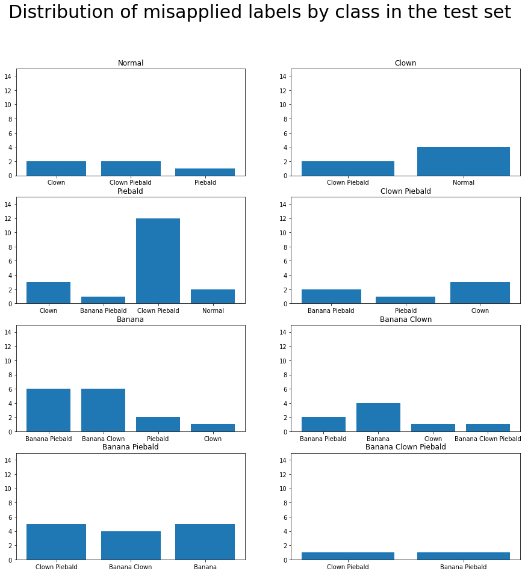

```python
fig, axs = plt.subplots(4, 2, sharey=False, tight_layout=False, figsize=(15,15), facecolor='white')

fig.suptitle('Distribution of misapplied labels by class in the test set', fontsize=30)
n = 0
for i in range(0,4):
    for j in range(0,2):
        axs[i,j].bar(confusion_collection[n].keys(), confusion_collection[n].values())
        axs[i,j].set(title=snake_encoder[n])
        axs[i,j].set_ylim(top=15) # Normalize the y-axis to get a better idea of the distributions relative to each other
        #n=random.randint(0, len(X_train))
        n = n + 1

#plt.bar(confusion_collection[2].keys(), confusion_collection[2].values())
#plt.title("Number of times a", snake_encoder)
#plt.show()
```

Snakes tend to get mislabelled as categories that are at least somewhat similar to the true category--for instance, banana clown snakes tend to get confused with classes containing banana and classes containing clown. For any given class, the distribution of snakes among labels with a non-zero count tends to be fairly uniform, with one obvious exception: there is a disproportionate number of piebald snakes that were mislabelled as clown piebald. Let's take a look at the snakes that were mislabelled as clown piebald.

[figure not shown]

```python
not_clowns = list()
for snake in confused_snakes:
    (x, y_true, y_pred) = snake
    if y_true == 2 and y_pred == 3:
        not_clowns.append(x)

fig, axs = plt.subplots(3, 4, sharey=False, tight_layout=True, figsize=(12,6), facecolor='white')
n= 0
fig.suptitle('Piebald ball pythons mislabelled as clown piebald', fontsize=30)
for i in range(0,3):
    for j in range(0,4):
        axs[i,j].matshow(not_clowns[n])
        n = n + 1
plt.show()
```

And compare with images of actual clown piebald ball pythons.

[figure not shown]

```python
random.seed(300)
fig, axs = plt.subplots(3, 4, sharey=False, tight_layout=True, figsize=(12,7), facecolor='white')
fig.suptitle('Actual clown piebald ball pythons', fontsize=30)
n = 0
for i in range(0,3):
    for j in range(0,4):
        axs[i,j].matshow(df_list[3].iloc[random.randint(0, len(df_list[3])-1)]['img'])
        n=n+1
plt.show()
```

The two groups look incredibly similar, even though there are differences in the head stamps of the snakes that sets them apart--these are obvious to someone familiar with ball python morphs but not so much to an uninformed person, let alone a neural network. I believe the reason for this confusion is that the piebald gene itself doesn't just cause a white blocking in the snakes--it also "brightens" up the nonwhite portions of the snake, bringing them closer in color to a clown ball python's coloration. I am not surprised that the neural network keeps confusing these snakes.

## B: Exploring How Categorical Variables Influence Price and Number of Likes

### Part 1: Data Wrangling

The other big thing that I wanted to explore for this project is how traits, sex and age affect the price of the snake. My guess is that breeders will adjust the prices of their snakes based upon how old it is, what traits it has, and the age of the snake. However, we'll need to do some data exploration and hypothesis testing before drawing any conclusions. We'll once again display the united dataframe:

```python
united_df.head()
```

|  | Unnamed: 0 | img_url | sex | traits | birth | weight | diet | breeder | location | price | ... | group_id | origin | num_likes | snake_url | img | title | isBanana | isPiebald | isClown | cat_encoder |
| --- | --- | --- | --- | --- | --- | --- | --- | --- | --- | --- | --- | --- | --- | --- | --- | --- | --- | --- | --- | --- | --- |
| 0 | 0 | https://d20zyr0oabjxc2.cloudfront.net/variants... | male | {'Normal'} | 1st April 2022 | NaN | Frozen/Thawed Mouse | XYZReptiles | Palmetto Bay, Florida | US$69.00 | ... | NaN | Domestically Produced | 6 | https://www.morphmarket.com/us/c/reptiles/pyth... | <PIL.JpegImagePlugin.JpegImageFile image mode=... | Baby Normal | 0 | 0 | 0 | 0 |
| 1 | 1 | https://d20zyr0oabjxc2.cloudfront.net/variants... | female | {'Normal'} | 1st April 2022 | NaN | Frozen/Thawed Mouse | XYZReptiles | Palmetto Bay, Florida | US$69.00 | ... | NaN | Domestically Produced | 18 | https://www.morphmarket.com/us/c/reptiles/pyth... | <PIL.JpegImagePlugin.JpegImageFile image mode=... | Baby Normal | 0 | 0 | 0 | 0 |
| 2 | 2 | https://d20zyr0oabjxc2.cloudfront.net/variants... | female | {'Normal'} | 2022 | 245g | NaN | Breeder'sCircle | Madison, Wisconsin | US$50.00 | ... | NaN | NaN | 0 | https://www.morphmarket.com/us/c/reptiles/pyth... | <PIL.JpegImagePlugin.JpegImageFile image mode=... | Normal | 0 | 0 | 0 | 0 |
| 3 | 3 | https://d20zyr0oabjxc2.cloudfront.net/variants... | female | {'Normal'} | 1st September 2022 | 126g | Live Rat | Python Antics | Albuquerque, New Mexico | US$20.00 | ... | NaN | NaN | 0 | https://www.morphmarket.com/us/c/reptiles/pyth... | <PIL.JpegImagePlugin.JpegImageFile image mode=... | 0922-04 | 0 | 0 | 0 | 0 |
| 4 | 4 | https://d20zyr0oabjxc2.cloudfront.net/variants... | male | {'Normal'} | 1st September 2022 | 125g | Live Rat | Python Antics | Albuquerque, New Mexico | US$20.00 | ... | NaN | NaN | 0 | https://www.morphmarket.com/us/c/reptiles/pyth... | <PIL.JpegImagePlugin.JpegImageFile image mode=... | 0922-05 | 0 | 0 | 0 | 0 |

5 rows × 26 columns

Now, we'll display the format that the prices for each snake take on.

```python
united_df['price'].unique()
```

```
array(['US$69.00', 'US$50.00', 'US$20.00', 'US$200.00', 'US$75.00',
       'GB£75.00 (Approx. US$90.97)', 'US$30.00', 'US$110.00',
       'US$1,250.00', 'GB£20.00 (Approx. US$24.26)',
       'GB£100.00 (Approx. US$121.29)', 'US$25.00', 'US$74.99',
       'US$99.00', 'US$250.00', 'GB£60.00 (Approx. US$72.78)',
       'US$300.00', '25.00 € (Approx. US$26.17)', 'US$100.00', 'US$60.00',
       'US$225.00', 'US$90.00', 'GB£30.00 (Approx. US$36.39)', 'US$55.00',
       '100.00 € (Approx. US$104.67)', 'US$140.00', 'US$40.00',
       'US$35.00', 'C$150.00 (Approx. US$109.89)', 'US$150.00',
       'Mex$2,500.00 (Approx. US$126.28)', 'US$275.00', 'US$325.00',
       'US$249.99', 'US$69.99', 'US$199.00', 'US$179.00', 'US$149.00',
       'US$85.00', 'GB£35.00 (Approx. US$42.45)',
       '120.00 € (Approx. US$125.60)', 'GB£10.00 (Approx. US$12.13)',
       'US$80.00', 'US$350.00', 'US$500.00',
       'GB£15.00 (Approx. US$18.19)', 'US$65.00',
       'R1,800.00 (Approx. US$103.89)', 'US$400.00', 'US$125.00',
       'Mex$2,400.00 (Approx. US$121.23)', 'GB£90.00 (Approx. US$109.16)',
       'GB£25.00 (Approx. US$30.32)', 'US$299.00', 'US$399.99',
       'US$130.00', 'US$8,000.00', '275.00 € (Approx. US$287.83)',
       '300.00 € (Approx. US$314.00)', 'C$250.00 (Approx. US$183.15)',
       'US$450.00', '180.00 € (Approx. US$188.40)',
       '80.00 € (Approx. US$83.73)', 'US$395.00',
       'C$400.00 (Approx. US$293.04)', '750.00 € (Approx. US$785.00)',
       'GB£150.00 (Approx. US$181.94)', 'GB£240.00 (Approx. US$291.10)',
       '200.00 € (Approx. US$209.33)', 'GB£525.00 (Approx. US$636.79)',
       'Please Inquire', 'US$297.00', 'US$197.00',
       'R3,000.00 (Approx. US$173.14)', 'US$330.00',
       'GB£200.00 (Approx. US$242.59)', 'GB£250.00 (Approx. US$303.23)',
       'US$399.00', 'US$175.00', 'US$235.00', 'US$375.00', 'US$1,500.00',
       'US$1,125.00', '150.00 € (Approx. US$157.00)', 'US$2,000.00',
       'US$120.00', 'GB£135.00 (Approx. US$163.74)',
       '99.00 € (Approx. US$103.62)', 'GB£175.00 (Approx. US$212.26)',
       'GB£300.00 (Approx. US$363.88)', 'GB£195.00 (Approx. US$236.52)',
       'GB£160.00 (Approx. US$194.07)', 'GB£275.00 (Approx. US$333.55)',
       'GB£185.00 (Approx. US$224.39)', 'GB£295.00 (Approx. US$357.81)',
       'C$425.00 (Approx. US$311.36)', 'US$425.00',
       '225.00 € (Approx. US$235.50)', '350.00 € (Approx. US$366.33)',
       '550.00 € (Approx. US$575.66)', 'US$1,200.00',
       'GB£325.00 (Approx. US$394.20)', 'GB£350.00 (Approx. US$424.52)',
       '1,000.00 € (Approx. US$1,046.66)', 'US$475.00', 'US$459.99',
```

[output cut: 47 more lines]

```
       'GB£290.00 (Approx. US$351.75)', 'US$385.20', 'US$1,400.00',
       'R5,000.00 (Approx. US$288.57)', 'GB£395.00 (Approx. US$479.11)',
       'R15,000.00 (Approx. US$865.71)', 'US$2,800.00', 'US$1,700.00',
       'C$800.00 (Approx. US$586.08)', 'GB£180.00 (Approx. US$218.33)',
       'GB£390.00 (Approx. US$473.04)', 'GB£495.00 (Approx. US$600.40)',
       'GB£276.50 (Approx. US$335.37)', 'GB£147.50 (Approx. US$178.91)',
       'US$499.99', 'GB£1,750.00 (Approx. US$2,122.62)',
       'R3,500.00 (Approx. US$202.00)', 'US$8,500.00',
       'GB£850.00 (Approx. US$1,030.99)', 'GB£437.50 (Approx. US$530.65)',
       'US$799.00', 'US$1,300.00', 'US$2,700.00',
       'C$500.00 (Approx. US$366.30)', 'US$295.00',
       '375.00 € (Approx. US$392.50)', 'US$324.00',
       'GB£2,500.00 (Approx. US$3,032.31)',
       '4,250.00 € (Approx. US$4,448.31)',
       '3,950.00 € (Approx. US$4,134.31)', 'US$609.00'], dtype=object)
```

It looks like that prices are generally either directly listed in USD, or they are listed in a different currency--in which case, the approximate USD price will be displayed afterwards. This should make it easy to extract integer values for each snake with some regex processing.

```python
print('nan prices:', united_df['price'].isna().sum())
united_df['usd_price'] = united_df['price'].apply(lambda x: re.search('US\$[0-9,]*\.[0-9]*', x))
united_df.loc[united_df['usd_price'].isna()]
```

```
nan prices: 0
```

|  | Unnamed: 0 | img_url | sex | traits | birth | weight | diet | breeder | location | price | ... | origin | num_likes | snake_url | img | title | isBanana | isPiebald | isClown | cat_encoder | usd_price |
| --- | --- | --- | --- | --- | --- | --- | --- | --- | --- | --- | --- | --- | --- | --- | --- | --- | --- | --- | --- | --- | --- |
| 79 | 79 | https://d20zyr0oabjxc2.cloudfront.net/variants... | female | {'Clown'} | 2020 | NaN | Frozen/Thawed Mouse | Firststrike | Edmonton, Alberta | Please Inquire | ... | NaN | 41 | https://www.morphmarket.com/ca/c/reptiles/pyth... | <PIL.JpegImagePlugin.JpegImageFile image mode=... | Warlock Clown | 0 | 0 | 1 | 1 | None |

1 rows × 27 columns

This particular listing has a price listing of 'Please Inquire', which isn't a nan, but nonetheless doesn't have a numeric value associated with it. We will have to toss out this listing for the purposes of this part of the project:

```python
price_df = united_df.loc[united_df['usd_price'].notnull()]
price_df['str_usd_price'] = price_df['usd_price'].apply(lambda x: x.group(0))
price_df.head()
```

|  | Unnamed: 0 | img_url | sex | traits | birth | weight | diet | breeder | location | price | ... | num_likes | snake_url | img | title | isBanana | isPiebald | isClown | cat_encoder | usd_price | str_usd_price |
| --- | --- | --- | --- | --- | --- | --- | --- | --- | --- | --- | --- | --- | --- | --- | --- | --- | --- | --- | --- | --- | --- |
| 0 | 0 | https://d20zyr0oabjxc2.cloudfront.net/variants... | male | {'Normal'} | 1st April 2022 | NaN | Frozen/Thawed Mouse | XYZReptiles | Palmetto Bay, Florida | US$69.00 | ... | 6 | https://www.morphmarket.com/us/c/reptiles/pyth... | <PIL.JpegImagePlugin.JpegImageFile image mode=... | Baby Normal | 0 | 0 | 0 | 0 | <re.Match object; span=(0, 8), match='US$69.00'> | US$69.00 |
| 1 | 1 | https://d20zyr0oabjxc2.cloudfront.net/variants... | female | {'Normal'} | 1st April 2022 | NaN | Frozen/Thawed Mouse | XYZReptiles | Palmetto Bay, Florida | US$69.00 | ... | 18 | https://www.morphmarket.com/us/c/reptiles/pyth... | <PIL.JpegImagePlugin.JpegImageFile image mode=... | Baby Normal | 0 | 0 | 0 | 0 | <re.Match object; span=(0, 8), match='US$69.00'> | US$69.00 |
| 2 | 2 | https://d20zyr0oabjxc2.cloudfront.net/variants... | female | {'Normal'} | 2022 | 245g | NaN | Breeder'sCircle | Madison, Wisconsin | US$50.00 | ... | 0 | https://www.morphmarket.com/us/c/reptiles/pyth... | <PIL.JpegImagePlugin.JpegImageFile image mode=... | Normal | 0 | 0 | 0 | 0 | <re.Match object; span=(0, 8), match='US$50.00'> | US$50.00 |
| 3 | 3 | https://d20zyr0oabjxc2.cloudfront.net/variants... | female | {'Normal'} | 1st September 2022 | 126g | Live Rat | Python Antics | Albuquerque, New Mexico | US$20.00 | ... | 0 | https://www.morphmarket.com/us/c/reptiles/pyth... | <PIL.JpegImagePlugin.JpegImageFile image mode=... | 0922-04 | 0 | 0 | 0 | 0 | <re.Match object; span=(0, 8), match='US$20.00'> | US$20.00 |
| 4 | 4 | https://d20zyr0oabjxc2.cloudfront.net/variants... | male | {'Normal'} | 1st September 2022 | 125g | Live Rat | Python Antics | Albuquerque, New Mexico | US$20.00 | ... | 0 | https://www.morphmarket.com/us/c/reptiles/pyth... | <PIL.JpegImagePlugin.JpegImageFile image mode=... | 0922-05 | 0 | 0 | 0 | 0 | <re.Match object; span=(0, 8), match='US$20.00'> | US$20.00 |

5 rows × 28 columns

```python
price_df['numeric_price'] = price_df['str_usd_price'].apply(lambda x: float(x.replace('US$', '').replace(',', '')))
price_df.head()
```

|  | Unnamed: 0 | img_url | sex | traits | birth | weight | diet | breeder | location | price | ... | snake_url | img | title | isBanana | isPiebald | isClown | cat_encoder | usd_price | str_usd_price | numeric_price |
| --- | --- | --- | --- | --- | --- | --- | --- | --- | --- | --- | --- | --- | --- | --- | --- | --- | --- | --- | --- | --- | --- |
| 0 | 0 | https://d20zyr0oabjxc2.cloudfront.net/variants... | male | {'Normal'} | 1st April 2022 | NaN | Frozen/Thawed Mouse | XYZReptiles | Palmetto Bay, Florida | US$69.00 | ... | https://www.morphmarket.com/us/c/reptiles/pyth... | <PIL.JpegImagePlugin.JpegImageFile image mode=... | Baby Normal | 0 | 0 | 0 | 0 | <re.Match object; span=(0, 8), match='US$69.00'> | US$69.00 | 69.0 |
| 1 | 1 | https://d20zyr0oabjxc2.cloudfront.net/variants... | female | {'Normal'} | 1st April 2022 | NaN | Frozen/Thawed Mouse | XYZReptiles | Palmetto Bay, Florida | US$69.00 | ... | https://www.morphmarket.com/us/c/reptiles/pyth... | <PIL.JpegImagePlugin.JpegImageFile image mode=... | Baby Normal | 0 | 0 | 0 | 0 | <re.Match object; span=(0, 8), match='US$69.00'> | US$69.00 | 69.0 |
| 2 | 2 | https://d20zyr0oabjxc2.cloudfront.net/variants... | female | {'Normal'} | 2022 | 245g | NaN | Breeder'sCircle | Madison, Wisconsin | US$50.00 | ... | https://www.morphmarket.com/us/c/reptiles/pyth... | <PIL.JpegImagePlugin.JpegImageFile image mode=... | Normal | 0 | 0 | 0 | 0 | <re.Match object; span=(0, 8), match='US$50.00'> | US$50.00 | 50.0 |
| 3 | 3 | https://d20zyr0oabjxc2.cloudfront.net/variants... | female | {'Normal'} | 1st September 2022 | 126g | Live Rat | Python Antics | Albuquerque, New Mexico | US$20.00 | ... | https://www.morphmarket.com/us/c/reptiles/pyth... | <PIL.JpegImagePlugin.JpegImageFile image mode=... | 0922-04 | 0 | 0 | 0 | 0 | <re.Match object; span=(0, 8), match='US$20.00'> | US$20.00 | 20.0 |
| 4 | 4 | https://d20zyr0oabjxc2.cloudfront.net/variants... | male | {'Normal'} | 1st September 2022 | 125g | Live Rat | Python Antics | Albuquerque, New Mexico | US$20.00 | ... | https://www.morphmarket.com/us/c/reptiles/pyth... | <PIL.JpegImagePlugin.JpegImageFile image mode=... | 0922-05 | 0 | 0 | 0 | 0 | <re.Match object; span=(0, 8), match='US$20.00'> | US$20.00 | 20.0 |

5 rows × 29 columns

We can visualize the distribution of the prices as a histogram below.

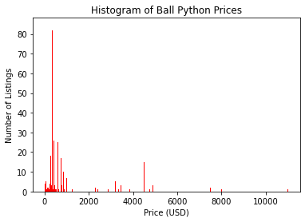

```python
plt.hist(price_df['numeric_price'], color = 'red', bins = int(9000/5))

# Add labels
plt.title('Histogram of Ball Python Prices')
plt.xlabel('Price (USD)')
plt.ylabel('Number of Listings')
```

It appears that the vast majority of listings are within the 0 to 1000 range, with a few listings reaching well beyond that range. The distribution here strongly resembles an exponential distribution, though it peaks at somewhere between 0 and 1000 instead of at 0. Let's see if we can find a relationship between age and price.

```python
price_df['birth'].isna().sum()
price_age_df = price_df.loc[price_df['birth'].notnull()]
price_age_df['preprocessedbirth'] = price_age_df['birth'].apply(lambda x: x.replace('st', '')\
                                                                .replace('th', '')\
                                                                .replace('nd', '')\
                                                                .replace('rd', '')\
                                                                .replace('Augu', 'August'))
price_age_df['preprocessedbirth'].unique()
```

```
array(['1 April 2022', '2022', '1 September 2022', 'September 2022',
       '19 September 2022', '2020', '14 August 2022', '16 September 2021',
       '23 May 2021', '2019', '6 June 2022', '22 October 2020',
       '10 April 2019', 'June 2022', '8 July 2014', '8 June 2022',
       '30 August 2022', '4 July 2021', '3 October 2009',
       '1 October 2009', 'November 2022', '28 August 2022',
       '26 August 2022', '2012', '6 July 2022', '2018', '29 August 2022',
       '25 June 2022', '2010', '15 September 2022', '8 August 2022',
       'October 2021', '1 October 2022', 'August 2021', '11 August 2022',
       '5 July 2022', '3 August 2022', '2021', '2009',
       '10 September 2022', '22 July 2022', 'July 2021', '12 June 2022',
       'May 2021', '25 September 2022', 'August 2022', '14 May 2022',
       '15 July 2022', '15 June 2022', '11 December 2021',
       '19 November 2021', '2013', '25 May 2022', '16 September 2022',
       '2017', '4 June 2022', '6 September 2022', 'January 2018',
       '12 October 2022', '8 July 2022', '13 August 2022', 'July 2022',
       '10 March 2022', 'July 2019', '7 July 2021', '25 September 2021',
       '15 April 2022', '22 April 2022', '13 June 2022', '23 August 2022',
       '24 April 2022', '2016', '1 July 2022', '11 September 2021',
       '27 July 2022', '6 June 2020', 'October 2022', '30 June 2022',
       '21 July 2021', '26 August 2021', '1 September 2021',
       '22 August 2021', '25 July 2022', '1 June 2021', '31 July 2022',
       '16 June 2022', '9 November 2022', '16 July 2022', '1 August 2022',
       '3 July 2021', '2 September 2021', '20 August 2022',
       '10 November 2022', '3 November 2022', 'July 2020',
       '19 August 2022', '17 August 2021', '21 September 2022',
       '7 August 2022', '4 July 2022', '21 July 2019', '21 October 2022',
       '6 October 2022', '29 October 2022', '22 February 2018',
       'November 2021', '30 April 2022', '2 May 2022', '20 May 2022',
       '10 May 2022', '24 August 2022', '28 March 2021',
       '15 September 2021', '12 April 2022', '9 September 2022',
       '27 August 2022', '19 July 2021', '24 July 2022', '29 July 2021',
       '9 August 2022', '23 September 2022', '30 September 2022',
       'April 2022', 'May 2022', '17 August 2022', '6 August 2022',
       '20 September 2022', '28 July 2022', '24 May 2022', '2015',
       '10 June 2022', 'March 2022', '22 August 2022', '16 August 2022',
       '4 September 2022', '7 June 2022', '30 October 2022',
       '13 July 2021', '1 November 2022', '17 November 2021',
       '10 October 2022', '8 October 2022', '12 July 2022',
       '12 August 2022', '26 February 2021', '24 January 2021',
```

[output cut: 13 more lines]

```
       'October 2018', '7 July 2018', '23 July 2022', '9 September 2021',
       '13 August 2020', '26 July 2017', '4 October 2022',
       '21 August 2022', '21 October 2021', '26 October 2021',
       '7 June 2020', '4 June 2017', '28 September 2018',
       '19 December 2021', '24 July 2021', '3 November 2021',
       '23 August 2021', '11 September 2017', '2 April 2022',
       'September 2021', '3 June 2021', '6 August 2021', '2 July 2021',
       '10 August 2021', '17 September 2021', '5 October 2022',
       '20 February 2022', '23 March 2022', '28 May 2021',
       '19 October 2022', '18 October 2022', 'July 2017',
       '22 October 2022', '10 November 2021', '26 June 2022',
       '25 October 2022', '6 August 2020', '29 June 2021',
       '2 August 2022', '18 June 2022', 'December 2021', '30 July 2022',
       '23 June 2022', '15 August 2022', '18 July 2022',
       '17 October 2022', '25 June 2021', '20 May 2021'], dtype=object)
```

While all non-nan listings have a birth year, not all listings have a birthday or even a birth month. I will fill in the missing days and missing months as "7" and "July", respectively. Then, we can convert all the birth dates to number of days old.

```python
from datetime import datetime
today = datetime.now()
price_age_df['missing_month'] = price_age_df['preprocessedbirth'].apply(lambda x: 'July ' + x if re.search('^[0-9]{4}$', x) is not None else x)
price_age_df['missing_day'] = price_age_df['missing_month'].apply(lambda x: '7 ' + x if re.search('^[a-zA-Z]* [0-9]{4}$', x) is not None else x)
price_age_df['datetime'] = price_age_df['missing_day'].apply(lambda x: datetime.strptime(x, '%d %B %Y'))
price_age_df['days_old'] = price_age_df['datetime'].apply(lambda x: (today - x).days)
price_age_df.head()
```

|  | Unnamed: 0 | img_url | sex | traits | birth | weight | diet | breeder | location | price | ... | isClown | cat_encoder | usd_price | str_usd_price | numeric_price | preprocessedbirth | missing_month | missing_day | datetime | days_old |
| --- | --- | --- | --- | --- | --- | --- | --- | --- | --- | --- | --- | --- | --- | --- | --- | --- | --- | --- | --- | --- | --- |
| 0 | 0 | https://d20zyr0oabjxc2.cloudfront.net/variants... | male | {'Normal'} | 1st April 2022 | NaN | Frozen/Thawed Mouse | XYZReptiles | Palmetto Bay, Florida | US$69.00 | ... | 0 | 0 | <re.Match object; span=(0, 8), match='US$69.00'> | US$69.00 | 69.0 | 1 April 2022 | 1 April 2022 | 1 April 2022 | 2022-04-01 | 259 |
| 1 | 1 | https://d20zyr0oabjxc2.cloudfront.net/variants... | female | {'Normal'} | 1st April 2022 | NaN | Frozen/Thawed Mouse | XYZReptiles | Palmetto Bay, Florida | US$69.00 | ... | 0 | 0 | <re.Match object; span=(0, 8), match='US$69.00'> | US$69.00 | 69.0 | 1 April 2022 | 1 April 2022 | 1 April 2022 | 2022-04-01 | 259 |
| 2 | 2 | https://d20zyr0oabjxc2.cloudfront.net/variants... | female | {'Normal'} | 2022 | 245g | NaN | Breeder'sCircle | Madison, Wisconsin | US$50.00 | ... | 0 | 0 | <re.Match object; span=(0, 8), match='US$50.00'> | US$50.00 | 50.0 | 2022 | July 2022 | 7 July 2022 | 2022-07-07 | 162 |
| 3 | 3 | https://d20zyr0oabjxc2.cloudfront.net/variants... | female | {'Normal'} | 1st September 2022 | 126g | Live Rat | Python Antics | Albuquerque, New Mexico | US$20.00 | ... | 0 | 0 | <re.Match object; span=(0, 8), match='US$20.00'> | US$20.00 | 20.0 | 1 September 2022 | 1 September 2022 | 1 September 2022 | 2022-09-01 | 106 |
| 4 | 4 | https://d20zyr0oabjxc2.cloudfront.net/variants... | male | {'Normal'} | 1st September 2022 | 125g | Live Rat | Python Antics | Albuquerque, New Mexico | US$20.00 | ... | 0 | 0 | <re.Match object; span=(0, 8), match='US$20.00'> | US$20.00 | 20.0 | 1 September 2022 | 1 September 2022 | 1 September 2022 | 2022-09-01 | 106 |

5 rows × 34 columns

### Part 2: Data Exploration

I would like to see how the different attributes of a ball python affect its price, such as sex, age and traits. We can create a linear regression of the data including attributes as interaction terms.

Now that we have a numeric value for how old a ball python is, we can plot a scatter plot of ball python ages versus prices to see if there's a clear relationship.

```
coefficient 0.5128102314466285
intercept 697.2601626784286
```

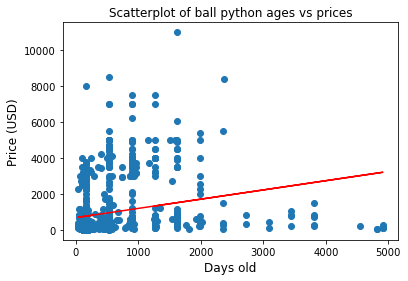

```python
plt.scatter(price_age_df['days_old'], price_age_df['numeric_price'])
plt.title('Scatterplot of ball python ages vs prices', fontsize='large')
plt.xlabel('Days old', fontsize='large')
plt.ylabel('Price (USD)', fontsize='large')

linear_regressor = LinearRegression()  # create object for the class
linear_regressor.fit(price_age_df['days_old'].values.reshape(-1, 1), price_age_df['numeric_price'].values.reshape(-1, 1))  # perform linear regression
Y_pred = linear_regressor.predict(price_age_df['days_old'].values.reshape(-1, 1))  # make predictions
plt.plot(price_age_df['days_old'].values.reshape(-1, 1), Y_pred, color='red')
print("coefficient", linear_regressor.coef_[0][0])
print("intercept", linear_regressor.intercept_[0])
```

It appears that most snakes tend to be relatively young. Additionally, there isn't an obvious relationship between age and price. No snake that is older than about 2500 days has a price above 2000, but despite this, the linear regression has predicted a positive relationship between age and price. Let's see if other attributes will bring more clarity to the situation.

In the ball python breeding industry, female ball pythons are more valued than male ball pythons because a male ball python takes far less time to successfully reproduce than a female does. Let's visualize the distribution of prices by sex. Seaborn includes functions that allow you to easily make box plots, violin plots and more.

```
Average male ball python price in USD: 788.7709869375907
Average female ball python price in USD: 1216.4681855670106
```

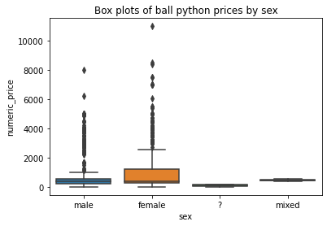

```python
sns.boxplot(x='sex', y='numeric_price', data=price_age_df).set(title = 'Box plots of ball python prices by sex')
print('Average male ball python price in USD:', price_age_df.loc[price_age_df['sex'] == 'male']['numeric_price'].mean())
print('Average female ball python price in USD:', price_age_df.loc[price_age_df['sex'] == 'female']['numeric_price'].mean())
```

While the difference is slight, female ball pythons do seem to have a stronger skew upwards than male ball pythons. In addition, the average price for female ball pythons is approximately 400 USD higher than male ball pythons. Some of the listings have unsexed ball pythons, indicated as '?'. Other listings have multiple ball pythons of different sexes, which is indicated as 'mixed'. We can encode whether a ball python is female as an integer.

```python
price_age_df['isFemale'] = price_age_df['sex'].apply(lambda x: 1 if x == 'female' else 0)
price_age_df.head()
```

|  | Unnamed: 0 | img_url | sex | traits | birth | weight | diet | breeder | location | price | ... | cat_encoder | usd_price | str_usd_price | numeric_price | preprocessedbirth | missing_month | missing_day | datetime | days_old | isFemale |
| --- | --- | --- | --- | --- | --- | --- | --- | --- | --- | --- | --- | --- | --- | --- | --- | --- | --- | --- | --- | --- | --- |
| 0 | 0 | https://d20zyr0oabjxc2.cloudfront.net/variants... | male | {'Normal'} | 1st April 2022 | NaN | Frozen/Thawed Mouse | XYZReptiles | Palmetto Bay, Florida | US$69.00 | ... | 0 | <re.Match object; span=(0, 8), match='US$69.00'> | US$69.00 | 69.0 | 1 April 2022 | 1 April 2022 | 1 April 2022 | 2022-04-01 | 259 | 0 |
| 1 | 1 | https://d20zyr0oabjxc2.cloudfront.net/variants... | female | {'Normal'} | 1st April 2022 | NaN | Frozen/Thawed Mouse | XYZReptiles | Palmetto Bay, Florida | US$69.00 | ... | 0 | <re.Match object; span=(0, 8), match='US$69.00'> | US$69.00 | 69.0 | 1 April 2022 | 1 April 2022 | 1 April 2022 | 2022-04-01 | 259 | 1 |
| 2 | 2 | https://d20zyr0oabjxc2.cloudfront.net/variants... | female | {'Normal'} | 2022 | 245g | NaN | Breeder'sCircle | Madison, Wisconsin | US$50.00 | ... | 0 | <re.Match object; span=(0, 8), match='US$50.00'> | US$50.00 | 50.0 | 2022 | July 2022 | 7 July 2022 | 2022-07-07 | 162 | 1 |
| 3 | 3 | https://d20zyr0oabjxc2.cloudfront.net/variants... | female | {'Normal'} | 1st September 2022 | 126g | Live Rat | Python Antics | Albuquerque, New Mexico | US$20.00 | ... | 0 | <re.Match object; span=(0, 8), match='US$20.00'> | US$20.00 | 20.0 | 1 September 2022 | 1 September 2022 | 1 September 2022 | 2022-09-01 | 106 | 1 |
| 4 | 4 | https://d20zyr0oabjxc2.cloudfront.net/variants... | male | {'Normal'} | 1st September 2022 | 125g | Live Rat | Python Antics | Albuquerque, New Mexico | US$20.00 | ... | 0 | <re.Match object; span=(0, 8), match='US$20.00'> | US$20.00 | 20.0 | 1 September 2022 | 1 September 2022 | 1 September 2022 | 2022-09-01 | 106 | 0 |

5 rows × 35 columns

Earlier, we had one-hot encoded traits as integer values. We can predict a linear regression with not just price, but also including traits and sex as interaction terms. For each term, I will arbitrarily set a P-value of 0.05. This P-value means that if the chances of obtaining a particular event are less than 0.05, then I should reject the null hypothesis claiming that there is no relationship between the price of a ball python and its other attributes.

```python
price_age_X = price_age_df[['days_old', 'isClown', 'isPiebald', 'isBanana', 'isFemale']]
X2 = sm.add_constant(price_age_X)
est = sm.OLS(price_age_df['numeric_price'].values.reshape(-1, 1), X2)
est2 = est.fit()
print(est2.summary())
```

```
                            OLS Regression Results
==============================================================================
Dep. Variable:                      y   R-squared:                       0.552
Model:                            OLS   Adj. R-squared:                  0.550
Method:                 Least Squares   F-statistic:                     291.0
Date:                Fri, 16 Dec 2022   Prob (F-statistic):          6.59e-203
Time:                        11:45:56   Log-Likelihood:                -9808.1
No. Observations:                1186   AIC:                         1.963e+04
Df Residuals:                    1180   BIC:                         1.966e+04
Df Model:                           5
Covariance Type:            nonrobust
==============================================================================
                 coef    std err          t      P>|t|      [0.025      0.975]
------------------------------------------------------------------------------
const       -826.9618     69.766    -11.853      0.000    -963.840    -690.083
days_old       0.4180      0.044      9.409      0.000       0.331       0.505
isClown     1514.1485     57.488     26.339      0.000    1401.359    1626.938
isPiebald   1561.4915     57.592     27.113      0.000    1448.497    1674.486
isBanana     127.4070     60.046      2.122      0.034       9.598     245.216
isFemale     432.2575     58.798      7.352      0.000     316.897     547.618
==============================================================================
Omnibus:                      568.886   Durbin-Watson:                   0.844
Prob(Omnibus):                  0.000   Jarque-Bera (JB):             5836.231
Skew:                           1.961   Prob(JB):                         0.00
Kurtosis:                      13.135   Cond. No.                     2.85e+03
==============================================================================

Notes:
[1] Standard Errors assume that the covariance matrix of the errors is correctly specified.
[2] The condition number is large, 2.85e+03. This might indicate that there are
strong multicollinearity or other numerical problems.
```

Every single variable that we tested on has a P-value less than 0.05! In fact, all of them save for 'isBanana' have a P-value of approximately 0. In addition, the P-value of the F-statistic is so small that it is essentially 0. Hence we can more or less reject the null hypothesis that breeders do not take these variables into account when deciding the price of their snakes.

The more interesting information comes from the exact coefficients that each variable imparts. The variables with the highest coefficients were isClown and isPiebald at approximately 1500 USD each; snakes with these traits on average were worth 1500USD more than snakes without these traits. isBanana, on the other hand, only gives a snake about 127 USD more in value. This makes more sense when taking into consideration how these genes manifest; clown and piebald are Mendelian recessive and only manifest if a snake has two copies of the gene, while banana is Mendelian dominant and will manifest as long as a snake has at least one copy of the gene. Therefore, a snake visually displaying clown or piebald is "harder" to get than a snake visually displaying banana.

Whether or not a snake was listed as female also influenced its price; female snakes are worth approximately 432 USD more than other snakes. This wasn't worth as much as whether or not a snake is visually clown or piebald, but worth more than whether or not a snake is visually banana. This sort of makes sense when considering that ball pythons hatching from a clutch have a 50/50 chance of being male or female regardless of the traits they possess, so female ball pythons aren't hard to produce compared to visual clowns or piebalds.

We can create a graph of residuals from the model.

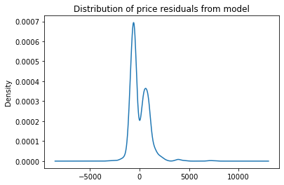

```python
price_age_df['price_residual'] = price_age_df['numeric_price'] - clf.coef_[0][0]*price_age_df['days_old'] - price_age_df['isClown'] * clf.coef_[0][1] - price_age_df['isPiebald'] * clf.coef_[0][2] - price_age_df['isBanana'] * clf.coef_[0][3] - price_age_df['isFemale'] * clf.coef_[0][4] - clf.intercept_[0]
price_age_df['price_residual'].plot.kde(title='Distribution of price residuals from model')
```

It looks like that there's still a lot of variation in the price residuals. I can see that the distribution appears to be bimodal, indicating that there's possibly still more variables to account for before all the variation goes away. We can compare this to a density plot of the original numeric prices:

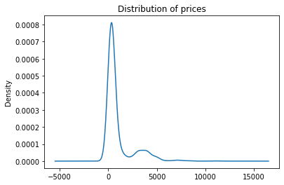

```python
price_age_df['numeric_price'].plot.kde(title='Distribution of prices')
```

The centering of the X-axes for both plots indicates that much of the rightward skew that was present in the original price distribution has been removed in the residual prediction. Additionally, there is a distinct bimodal presentation in the original distribution as well--it looks like these peaks shifted to be centered around 0.

## C: Conclusion

Throughout this project, we scraped ball python data from MorphMarket, trained a neural network on image data, and finally explored the relationship between price and other attributes of a snake. It is very possible to get a neural network to learn what the different traits of ball pythons look like, and have it achieve a decent accuracy in predicting the correct label. However, this task suffers from the curse of dimensionality as listed above, as well as the 'slowness' in new listings of more exotic trait combinations being posted. In addition, the bar plots of mislabelled snakes by class revealed an unexpected epiphany: clown piebalds and regular piebalds are colored very similarly. In the future, with more resources and data, a neural network might be able to distinguish between many morphs and combinations thereof.

As for exploring the relationship between price and other attributes, it comes as no surprise to me that some of the variation in price can be explained by the sex, traits and age of a snake. The specific effects each variable had on price were more interesting and reveal a "hierarchy" of sorts to the values that breeders put on attributes; recessive visuals had a much higher value than dominant visuals or the snake being female, even though the latter two traits also have a positive impact on the price of a snake.

Overall, I learned more than expected when I was doing this project on ball pythons. I hope you've learned something new and interesting about these funny snakes and that you've come to appreciate them some more.